# Thermodynamics

January 25th, 2021

Science of how:

- Temperature differences can be used to do work
  - Heat Engines
- Work can be used to make temperature differences
  - Refrigerators
- “Invented” by Sadi Carnot (*Reflections on the Motive Power of Fire*, Carnot 1824)
  - after early investigations by others
- But 1st, we need to understand **temperature**

## Zeroth law of Thermodynamics

- The zeroth law of thermodynamics helps us define temperature.
- Define Kelvin temperature scale:
  - Absolute 0 = $0 K$
  - Based on the $H_{2}O$ triple point $T_{3}$ = $273.16 K$
- 1 K = $\frac{T_{3}}{273.16}$
- If two bodies are in thermal equilibrium with a third body, they are also in thermal equilibrium with each other
- Enables use of thermometers – gives meaning to “temperature”
  - What do we mean by thermal equilibrium
    - Condition such that all the physical properties have stopped changing with time

**How do we measure temperature?** – Constant-Volume Gas Thermometer

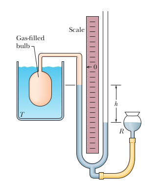

- Immerse bulb in liquid, wait until quilibrium
- Use Hg (mercury) manometer to measure change in gas pressure:
  - Adjust the height of the Hg reservoir $R$ to maintain constant gas volume
  - Use Hg height difference $h$ from left side to right side to determine $p$
- Then the desired temperature is $T = (273.16K) (\frac{p}{p_{3}})$
  - $p$ is the pressure of the gas at the measured temperature.
  - $p_{3}$ is the pressure at the triple point of water (273.16 K).
  - **More precisely** we use a limit for the fractional component, where gas approaches 0
  - $T = ( 273.16\ K ) ( \lim_{gas \to 0} \frac{p}{p_{3}} )$

## Celsius and Fahrenheit

- Celsius and Fahrenheit exist
- Conversions are simple

$$T_{C} = T - 273.15^{\circ}$$
$$T_{F} = \frac{9}{5} T_{C} + 32^{\circ}$$

Note that $T$ is implicitly Kelvin.

## Thermal Expansion

- Atoms and molecules are in constant motion
- As $T$ increases, their **kinetic energies** increase
  - Equilibrium intermolecular and interatomic separations increase
  - objects expand
- Length increase described by $\Delta L$ = $L \alpha \Delta T$ where $\alpha$ is the coefficient of linear expression, $\approx$ constant (small temperature dependence)
  - There is a table for $\alpha$ for substances in the slide (Units are given as $10^{-6}/C^{\circ}$)
- Volume expansion: consider cube with sides of length $L$
  - $V = L^{3}$
  - $\beta \approx 3 \alpha$
    - Good approximation

## Heat Absorption

- Heat $\equiv$ energy transferred from one body to another due to a temperature difference
  - e.g. from a system to its environment, or v.v.
- Units: joules (J), BTU, cal, or kcal
  - 1 cal = $3.968 \times 10^{-3}\ Btu$ = 4.1868 J

## Specific Heat

- **Heat capacity** $C$ of an object is proportionality constant between heat $Q$ absorbed or lost and resulting temperature change $\Delta T$ of object

$$Q = mc\Delta T$$

- Heat capacity per unit mass is the specific heat: $c = \frac{C}{m}$
  - Also useful is the **molar specific heat**, the heat capacity per mole
    - The specific heat across substances for molar units $\approx$ constant for metals.
  - Water has an unusually high specific heat
    - $C_{H_{2}0} = 1$ defines the calorie

## Heats of Transformation

- Phase changes (vaporizing, freezing, melting) occur at *constant* $T$
  - But still involves heat transfer $Q = Lm$
  - Where does the heat go? It transforms the material to a higher energy phase e.g. ice to water, water to water vapor.
- Heat of vaporization: $L_{V}$
  - This is the amount of energy per unit mass that must be
    - added to vaporize a liquid (phase change liquid to gas)
    - removed to condense a gas (phase change gas to liquid)
- Heat of fusion: $L_{F}$
  - This is the amount of energy per unit mass that must be
    - added to melt a solid (phase change solid to liquid)
    - removed to freeze a liquid (phase change liquid to solid)

## Heat & Work

- Thermodynamics was invented to guide development of more efficient heat engines.
- Consider a process that converts heat to work, i.e. having a gas expand to do work on a piston.
- If you raise the temperature of the gas, it’ll expand (gas does work on the piston), lower the temperature, it’ll contract (piston does work on the gas)

*Special Cases*

- Adiabatic: Q = 0 (insulation prevents heat transfer)
- Constant Volume: W = 0
- Closed Cycle: Q = W
- Free Expansion: Q = W = 0

## Conduction

Energy is transferred between an environment and an object via a conducting material.

## Convection

Convection occurs when there are temperature differences that cause an energy transfer by motion within a fluid. The process is described in detail in the textbook. In short, when a fluid comes in contact with an object that has a much higher temperature, the fluid expands (particles move faster) and it becomes less dense, and thus lighter. Buoyant forces make it rise, so then the cooler fluid flows, which is the motion.

## Radiation

An environment and an object can also exchange energy by radiation. Meaning, energy as heat can be transferred via electromagnetic waves. This radiation is often called thermal radiation to distinguish it from other waves on the electromagnetic spectrum, say the ones used in nuclear radiation and electromagnetic signals. For example, when you stand in front of a fire, you absorb heat energy from the fire via thermal radiation – the thermal energy of the fire thus decreases. **No medium** is required to transfer heat via radiation, which is why the Sun can transport thermal radiation through a vacuum. See the Formulas section for the rate at thermal radiation happens.

## Formulas

**Pressure and Temperature**

Considering other conditions are constant (i.e. volume), we say temperature is proportional to pressure

$$\begin{equation}
\label{eq:temp_pressure_rel}
T = Cp
\end{equation}$$

Where:

- $C$ is some constant

**Heat Transfer involved in Phase Changes**

$$\begin{equation}
\label{eq:phase_change_heat_transfer}
Q = Lm
\end{equation}$$

Where:

- For an object of mass $m$ and latent heat of $L$ (constant that can be found by a table as it depends on material), this formula gives the heat required $Q$ for a specific phase change

**Linear Expansion**

$$\begin{equation}
\label{eq:linear_expansion}
\Delta L = L \alpha \Delta T
\end{equation}$$

Where:

- $\alpha$ is the **coefficient of linear expansion**, this value depends on the material. It somewhat varies with temperature, but for most practical purposes it can be taken as a constant for a particular material.

**Volume Expansion** Change in volume $V$ of a solid or liquid is given by:

$$\begin{equation}
\label{eq:volume_expansion}
\Delta V = V \beta \Delta T
\end{equation}$$

Notes:

- $\beta = 3 \alpha$, this is the material’s coefficient of volume expansion
- $\alpha$ is the coefficient of linear expansion

Work done by a gas as it expands/contracts from an initial to a final volume:

$$\begin{equation}
\label{eq:gas_work}
W = \int_{}^{} dW = \int_{v_{i}}^{v_{f}} p dV
\end{equation}$$

First law of thermodynamics. This expresses how energy is conserved for a thermodynamic process:

$$\begin{equation}
\label{eq:thermo_first}
\Delta E_{int} = E_{int,\ f} - E_{int,\ i} = Q - W
\end{equation}$$

Notes:

- $\Delta E_{int}$ is the internal energy of the material, which depends only on the material’s state (temp, volume, pressure)
- $Q$ represents the energy exchanged as heat between the systems and its surroundings
  - It is **positive** when the system **absorbs** heat
  - It is **negative** when the system **loses** heat
- $W$ is the work done *by* the system
  - It is **positive** when the system **expands** against an external force
  - It is **negative** when the system **contracts** because of an external force
- This makes sense, because if both ($Q$ and $W$) were positive, then the gas would be absorbing heat and expanding, which is definitely a net increase in the energy. Conversely, if the gas were losing heat and contracting it would make sense that it is losing energy.
- $Q$ and $W$ are also path dependent, whereas $\Delta E_{int}$ is path independent
  - This means that $Q$ and $W$ do depend on the process that caused the change. Think of it in terms of the integral – the area under the curve can differ even if the starting and endpoint are the same. Conversely, $\Delta E_{int}$ is path independent.

Rate at which energy is conducted from a hot reservoir to a cold reservoir via a conducting slab:

$$\begin{equation}
\label{eq:thermal_conduction}
P_{cond} = \frac{Q}{t} = kA \frac{T_{H} - T_{C}}{L}
\end{equation}$$

Where:

- $P_{cond}$ is the rate which energy conducts through the slab (conduction rate)
- $t$ is the time of the process
- $Q$ is the energy transferred (as heat)
- Each face of the conducting slab has an area $A$
- $L$ is the length of the slab
- $k$ is the **thermal conductivity**, which is a constant that depends on the material of the slab. A material that can readily transfer energy conduction is naturally a good thermal conductor, and has a high value of $k$. There is a table for this for common metals, gases, and building materials in the textbook.

**Rate of Thermal Radiation Energy Emission**

$$\begin{equation}
\label{eq:radiation_energy_emission_rate}
P_{rad} = \sigma \varepsilon A T^{4}
\end{equation}$$

Notes:

- $\sigma$ is $5.6704 \times 10^{-8}\ W/m^{2} \cdot K^{4}$. This is called the *Stefan-Boltzmann* constant.
- $\varepsilon$ is the *emissivity* of the object’s surface. It has a value between 0 and 1. It depends on the composition of the surface.
  - A surface with an emissivity of 1.0 (the max) is better at radiating energy, because emissivity is the measure of an object’s ability to emit infrared energy.
- $T$ must be in Kelvins, it is the temperature of the area of the object
- Similarly, $A$ is the object’s surface area.

Similarly, there is a formula for the **rate of thermal radiation energy absorption**:

$$\begin{equation}
\label{eq:radiation_energy_absorption_rate}
P_{abs} = \sigma \varepsilon A T^{4}_{env}
\end{equation}$$

Notes:

- The emissivity is the same as the respective emission equation.

We can then determine the net heat transfer rate: (rate emitted - rate absorbed)?

$$\begin{equation}
\label{eq:net_heat_transfer_rate}
P_{net} = \sigma \varepsilon A T^{4} - \sigma \varepsilon A T^{4}_{env}
\end{equation}$$

R insulation formula

$$\begin{equation}
\label{eq:r_insulation_formula}
R = \frac{L}{k}
\end{equation}$$

Where:

- $L$ refers to the thickness of the material
- $k$ is the thermal conductivity of the material

Rate of conduction through multiple materials

$$\begin{equation}
\label{eq:multiple_material_conduction}
\frac{A (T_{H} - T_{C})}{\sum \frac{L}{k}}
\end{equation}$$

## Problems

### Question 68

This question is regarding **heats of transformation**.

> Icebergs in the North Atlantic present hazards to shipping, causing the lengths of shipping routes to be increased by about 30% during the iceberg season. Attempts to destroy icebergs include planting explosives, bombing, torpedoing, shelling, ramming, and coating with black soot. Suppose that direct melting of the iceberg, by placing heat sources in the ice, is tried. How much energy as heat is required to melt 10% of an iceberg that has a mass of 200,000 metric tons? (Use 1 metric ton = 1000 kg)

### Question 69

*This question has a figure required to answer the question. See the textbook for the question*

This question is regarding **the net change in internal energy due to work done and heat absorption**.

> Figure 18-51 displays a closed cycle for a gas. The change in internal energy along path `ca` is ‒160J. The energy transferred to the gas as heat is 200J along path `ab`, and 40J along path `bc`. How much work is done by the gas along path `abc` and path `ab`?

For this question, we notice that path `abca` is a closed path. Meaning, `abc` + `ca` = 0 (referring to the change in internal energy of each path). We know the change in internal energy for `ca`, as that is given to us. We also know that `bc` has a change of internal energy of 40J, since work cannot be done as the volume is constant (refer to the first law of thermodyanmics). Meaning, the change in internal energy of `ab` must be 120J. This means the work done by `ab` is 80J since 200 - 120 = 80 (first law of thermodynamics).

### Question 3

This question is regarding **temperature**. (The figure in this problem is not necessary to solve it)

> A gas thermometer is constructed of two gas-containing bulbs, each in a water bath, as shown in Fig. 18-30. The pressure difference between the two bulbs is measured by a mercury manometer as shown. Appropriate reservoirs, not shown in the diagram, maintain constant gas volume in the two bulbs. There is no difference in pressure when both baths are at the triple point of water. The pressure difference is 120 torr when one bath is at the triple point and the other is at the boiling point of water. It is 90.0 torr when one bath is at the triple point and the other is at an unknown temperature to be measured. What is the unknown temperature?

The question tells us that reservoirs maintain constant gas volume in the two bulbs. This means we can make the assumption that pressure will be proportional to the temperature, or $T = Cp$ for some constant $C$.

It tells us the pressure difference is 120 torr when one bulb is at the triple point of water (273.16 K) and the other is at the boiling point of water (373.1 K). We can represent the difference in temperature of the bulbs like so:

$$T_{1} - T_{2} = Cp_{1} - Cp_{2} = C (p_{1} - p_{2})$$

We can find the constant $C$ by substituting values for the aforementioned scenario:

$$373.1 - 273.16 = C (120)$$

$$C = \frac{99.94}{120}$$

Now, it asks us to find an unknown temperature knowing that the pressure difference is 90.0 torr when the other bulb is at the triple point of water. We can express this like so:

$$T_{1} - 273.16K = C (90)$$

We know the value of $C$, so we can substitute it in

$$T_{1} - 273.16K = \frac{99.94}{120} (90)$$

$$T_{1} = \frac{99.94}{120} (90) + 273.16K$$

$$T_{1} = 348.12 K$$

This is our answer, `348.12 K`.

### Question 7

This question is regarding **temperature scales**.

> Suppose that on a linear temperature scale X, water boils at $-53.5^{\circ}X$ and freezes at $-170^{\circ} X$. What is a temperature of 340 K on the X scale? (Approximate water’s boiling point as 373 K.)

Since the X temperature scale is linear, we can represent the temperature as $xa + b$ for some constants $a$ and $b$. Given two reference temperatures (boiling and freezing point of water) we can find these constants using a system:

$$273.16a + b = -170$$
$$373a + b = -53.5$$

Solving the system for $a$ and $b$ will produce the following conversion formula from Kelvin to X.

$$X(k) = 1.167k - 488.741$$

Question asks us for 340 K in X so we just pass it through the conversion formula we derived. Answer is $-92.1 X^{\circ}$.

### Question 7

This question is regarding **thermal expansion**.

> At $20^{\circ} C$, a brass cube has edge length 30 cm. What is the increase in the surface area when it is heated from $20^{\circ}C$ to $75^{\circ}C$?

$$\Delta L = L \alpha \Delta T$$

$$\Delta L = (30 / 100) (19 \times 10^{-6}) (55)$$

After calculating $\Delta L$, we can find the surface area. Then, we can take the difference. The difference comes out to be $11\text{ cm}^{2}$, our answer.

### Question 22

This question is regarding **absorption of heat**.

> One way to keep the contents of a garage from becoming too cold on a night when a severe subfreezing temperature is forecast is to put a tub of water in the garage. If the mass of the water is 125 kg and its initial temperature is $20^{\circ}C$
> - how much energy must the water transfer to its surroundings in order to freeze completely
> - what is the lowest possible temperature of the water and its surroundings until that happens?

First, the water must get to freezing temperature before the phase change can happen. Moreover, it has to transfer heat to its surroundings to reach that temperature. Consider the following:

$$Q = mc\Delta T$$

$$Q = (125 kg) (4187) (0 - 20)$$

This is the heat required to reach the temperature, to actually change phase will depend on the heat of fusion of water ($3.33 \times 10^{5}$)

$$Q = Lm$$

$$Q = - (3.33 \times 10^{5}) (125 kg)$$

Note: I added a negative sign here because for the freezing to happen energy has to be released from the system

Now, we can combine the two for the net heat needed for the water to come to the freezing point temperature and freeze:

$$Q = (125 kg) (4187) (0 - 20) + - (3.33 \times 10^{5}) (125 kg)$$

$$Q = -5.2 \times 10^{7}$$

Our answer is $5.2 \times 10^{7}\text{ J}$. It is positive since we are only interested in the amount of energy, aka the magnitude.

Part B asks us for the lowest possible temperature of the water and its surroundings until the freeze can happen. This is just $0^{\circ}\text{ C}$ because the phase change cannot happen until the temperature is below the freezing point.

### Question 33

This question is regarding **absorption of heat**.

> How long does a $2.0 \times 10^{5}\text{ Btu/h}$ water heater take to raise the temperature of 40 gal of water from $70^{\circ}F$ to $100^{\circ}F$?

First, let’s convert all of these quantities into their SI equivalents.

First, we should understand that for this temperature difference to happen heat needs to be added to the system. The question of how much heat is needed to be added is answered by the following formula, which takes as input a heat capacity (dependent on specific heat and mass) and the temperature difference.

$$Q = mc \Delta T$$

$$Q = 151.416 * 4187 * (23.6 - 6.9)$$

We know the specific heat of water is 4187. Now, we have calculated the heat energy required to make the temperature difference. Knowing this, and the rate at which energy is transferred (energy per unit time, or power), we can determine how long it would take to transfer this heat energy from the water heater.

$$t_{minutes} = \frac{151.416 * 4187 * (23.6 - 6.9)}{211012000} * 60$$

$$t_{minutes} = 3.0$$

Answer is then 3 minutes.

### Question 43

*This problem requires a necessary figure to solve the problem. See the textbook for the figure.* This question is regarding **the first law of thermodynamics**.

> In Fig. 18-37, a gas sample expands from $V_{0}$ to $4.0V_{0}$ while its pressure decreases from $p_{0}$ to $p_{0}$/4.0. If $V_{0}$ = $1.0\text{ }m^{3}$ and $p_{0}$ = 40 Pa, how much work is done by the gas if its pressure changes with volume via
> - path A
> - path B
> - path C

This question is fairly straightforward. We know that $w = pv$. So we find the area under the curve for each scenario.

Answers:

- Path A: 120 J
- Path B: 75 J
- Path C: 30 J

### Question 48

*This problem contains a figure that aids in answering the question, but not necessary to be able to solve it*

> As a gas is held within a closed chamber, it passes through the cycle shown in Fig. 18-41. Determine the energy transferred by the system as heat during constant-pressure process CA if the energy added as heat $Q_{AB}$ during constant-volume process AB is 20.0 J, no energy is transferred as heat during adiabatic process BC, and the net work done during the cycle is 15.0 J.

Since this is a cyclical process, we know that $\Delta E_{int} = 0$, or that $Q = W$. This means the work being done (W) is equal to the heat that is exchanged (Q). Well, it tells us that the net work of the cycle is 15.0 J. This means that the heat exchanged must be 15.0 J. We know that during process BC no energy is transferred, therefore, Q and W are 0 for that process. It tells us that for process AB $Q = 20.0J$. Therefore, $Q = -5$ for process CA.

### Question 51

This question is regarding **heat transfer mechanisms**.

> A sphere of radius 0.500m, temperature $27.0^{\circ}\text{ C}$, and emissivity 0.850 is located in an environment of temperature $77.0^{\circ}\text{ C}$. At what rate does the sphere
> - emit
> - absorb thermal radiation?
> - What is the sphere’s net rate of energy exchange?

Using the radiation formulas we can determine the quantities the question asks for.

First, let’s determine the surface area of the sphere:

$$A = 4 \pi 0.5^{2}$$

Now, let’s determine the emission rate:

This comes out to be `1.23 kW`.

Same thing for the absorption rate, just a different temperature to use:

This comes out to be `2.28 kW`.

The net rate is just `emission - absorption`, which comes out to be `-1.05 kW`.

### Question 52

This question is regarding **heat transfer mechanisms**.

> The ceiling of a single-family dwelling in a cold climate should have an R-value of 30. To give such insulation, how thick would a layer of
> - polyurethane foam
> - silver

> have to be?

The R value is derived from the thermal conductivity of the material. Specifically, it is inversely related because the material should be a bad thermal conductor if the insulation is to be good (which is what R is a measure of). Here is the formula for R:

$$R = \frac{L}{k}$$

Solve for L

$$L = Rk$$

The units for $R$ are very cringe because of the units it uses. The conversion factor from $R$ to RSI (standard) is $\frac{1}{5.678}$.

Now, we need the $k$ values for our materials:

- polyurethane foam = 0.024
- silver = 428

Simply solve for $L$ then for each material, answers are:

- polyurethane foam = `0.12672m`
- silver = `2259.84m`

### Question 57

This question is regarding **heat transfer mechanisms**.

> - What is the rate of energy loss in watts per square meter through a glass window 3.0 mm thick if the outside temperature is $-20^{\circ}\text{ F}$ and the inside temperature is $+72^{\circ}\text{ F}$?
> - A storm window having the same thickness of glass is installed parallel to the first window, with an air gap of 7.5 cm between the two windows. What now is the rate of energy loss if conduction is the only important energy-loss mechanism?

First, temperatures should be converted to Celsius or Kelvin.

$$P_{cond} = \frac{Q}{t} = kA \frac{T_{H} - T_{C}}{L}$$

Notice that the question asks for the rate of energy loss in watts **per square meter**, so:

$$\frac{Q}{At} = k \frac{T_{H} - T_{C}}{L}$$

Now, the first part of the problem can be solved by plugging the appropriate values for $k$, $T_{H}$, $T_{C}$ and $L$. Answer comes out to be $1.7 \times 10^{4}\ W/m^{2}$

$$\frac{T_{H} - T_{C}}{\frac{0.003}{1} + \frac{0.075}{0.026} + \frac{0.003}{1}}$$

We have all the values necessary to compute the answer, which is $17.68\ W/m^{2}$.